# Resistance in a Wire — Student Worksheet

**Unit: Current Electricity — Lesson 02** Name: _______________________ Date: __________ Period: ____

## Phenomenon

The same battery and the same bulb are connected first with a long, thin wire — the bulb glows dim. Then they’re connected with a short, thick wire — the bulb glows bright. The only thing that changed was the wire.

**Driving question:** What properties of a wire decide how much it resists the flow of charge?

## Notice & Wonder

| I notice… | I wonder… |
| --- | --- |

**Turn & Talk #1:** List every property of the *wire* that could change the brightness. Use the word *resistance*.

## Initial Model

At your group’s board, predict before you touch the simulation:

- If you make a wire **twice as long** (same thickness), what happens to its resistance R?
- If you make a wire **twice as thick** (double the cross-sectional area, same length), what happens to R?

> Length prediction: __________________________ Area prediction: ____________________________

## Investigation

Open PhET **Resistance in a Wire**. Change one slider at a time.

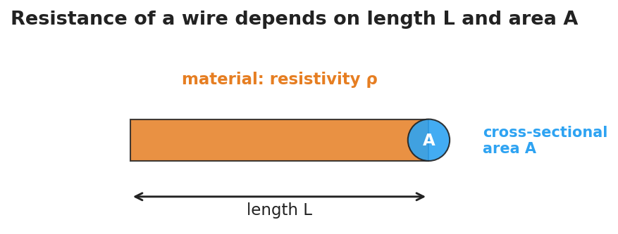

Diagram of a wire labeled with its length L, its circular end cap as cross-sectional area A, and the material’s resistivity rho.

**Part A — Vary length L** (keep ρ and A fixed):

| Length L (m) | Resistance R (Ω) |
| --- | --- |
| 1 |  |
| 2 |  |
| 3 |  |
| 4 |  |
| 5 |  |

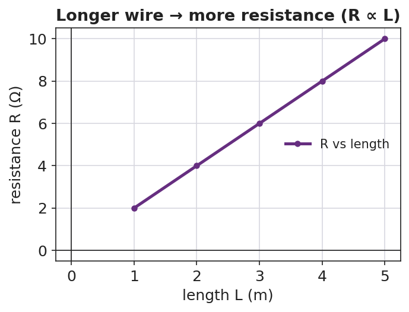

Line graph of resistance versus length showing a rising straight line: resistance is proportional to length.

**Part B — Vary area A** (keep ρ and L fixed). As area gets bigger, what happens to R?

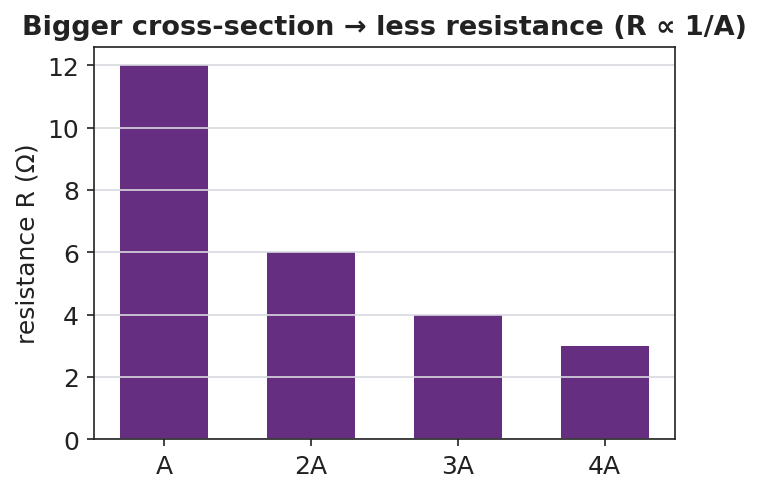

Bar chart of resistance versus cross-sectional area showing the bars get shorter as area increases.

**Part C — Material.** Increase the resistivity ρ slider. Does R go up or down?

**Key question:** Complete each pattern. R is **proportional to** __________ and **inversely proportional to** __________.

## Make It Make Sense

1. A wire is made twice as long with the same thickness. By what factor does its resistance change?
2. A wire is made twice as thick (double the area) with the same length. By what factor does its resistance change?
3. Copper has a low resistivity and nichrome has a high resistivity. Which makes a better connecting wire, and why?

## Vocabulary in Action

Use each term in a sentence about today’s phenomenon.

- **resistance:** _______________________________________________
- **resistivity:** _______________________________________________
- **cross-sectional area:** _______________________________________________

## Revise Your Model

Return to your Initial Model. Rewrite your explanation for why the long, thin wire dimmed the bulb, using *length*, *cross-sectional area*, and *resistance*.

## Exit Ticket

Two wires are made of the same material.

1. Wire B is twice as long as Wire A (same thickness). How does B’s resistance compare to A’s?
2. Wire C is twice as thick as Wire A (same length, double the cross-sectional area). How does C’s resistance compare to A’s?
3. Name one property of the material itself that affects resistance.